# Risk Factor Analysis

## Outcome Variable

**Outcome Variable:** ever_stunted

## Predictor Variables

**Intervention Variable:** nchldlt5

**Adjustment Set:**

unadjusted

## Stratifying Variables

The analysis was stratified on these variable(s):

- agecat
- studyid
- country

## Data Summary

| agecat | studyid | country | nchldlt5 | ever_stunted | n_cell | n |
| --- | --- | --- | --- | --- | --- | --- |
| 0-6 months | ki1000108-IRC | INDIA | 1 | 0 | 76 | 410 |
| 0-6 months | ki1000108-IRC | INDIA | 1 | 1 | 13 | 410 |
| 0-6 months | ki1000108-IRC | INDIA | 2 | 0 | 104 | 410 |
| 0-6 months | ki1000108-IRC | INDIA | 2 | 1 | 15 | 410 |
| 0-6 months | ki1000108-IRC | INDIA | 3+ | 0 | 180 | 410 |
| 0-6 months | ki1000108-IRC | INDIA | 3+ | 1 | 22 | 410 |
| 0-6 months | ki1017093b-PROVIDE | BANGLADESH | 1 | 0 | 461 | 700 |
| 0-6 months | ki1017093b-PROVIDE | BANGLADESH | 1 | 1 | 51 | 700 |
| 0-6 months | ki1017093b-PROVIDE | BANGLADESH | 2 | 0 | 161 | 700 |
| 0-6 months | ki1017093b-PROVIDE | BANGLADESH | 2 | 1 | 15 | 700 |
| 0-6 months | ki1017093b-PROVIDE | BANGLADESH | 3+ | 0 | 12 | 700 |
| 0-6 months | ki1017093b-PROVIDE | BANGLADESH | 3+ | 1 | 0 | 700 |
| 0-6 months | ki1017093c-NIH-Crypto | BANGLADESH | 1 | 0 | 467 | 758 |
| 0-6 months | ki1017093c-NIH-Crypto | BANGLADESH | 1 | 1 | 74 | 758 |
| 0-6 months | ki1017093c-NIH-Crypto | BANGLADESH | 2 | 0 | 180 | 758 |
| 0-6 months | ki1017093c-NIH-Crypto | BANGLADESH | 2 | 1 | 31 | 758 |
| 0-6 months | ki1017093c-NIH-Crypto | BANGLADESH | 3+ | 0 | 6 | 758 |
| 0-6 months | ki1017093c-NIH-Crypto | BANGLADESH | 3+ | 1 | 0 | 758 |
| 0-6 months | ki1066203-TanzaniaChild2 | TANZANIA, UNITED REPUBLIC OF | 1 | 0 | 1518 | 2385 |
| 0-6 months | ki1066203-TanzaniaChild2 | TANZANIA, UNITED REPUBLIC OF | 1 | 1 | 119 | 2385 |
| 0-6 months | ki1066203-TanzaniaChild2 | TANZANIA, UNITED REPUBLIC OF | 2 | 0 | 632 | 2385 |
| 0-6 months | ki1066203-TanzaniaChild2 | TANZANIA, UNITED REPUBLIC OF | 2 | 1 | 37 | 2385 |
| 0-6 months | ki1066203-TanzaniaChild2 | TANZANIA, UNITED REPUBLIC OF | 3+ | 0 | 75 | 2385 |
| 0-6 months | ki1066203-TanzaniaChild2 | TANZANIA, UNITED REPUBLIC OF | 3+ | 1 | 4 | 2385 |
| 0-6 months | ki1148112-LCNI-5 | MALAWI | 1 | 0 | 81 | 267 |
| 0-6 months | ki1148112-LCNI-5 | MALAWI | 1 | 1 | 41 | 267 |
| 0-6 months | ki1148112-LCNI-5 | MALAWI | 2 | 0 | 78 | 267 |
| 0-6 months | ki1148112-LCNI-5 | MALAWI | 2 | 1 | 44 | 267 |
| 0-6 months | ki1148112-LCNI-5 | MALAWI | 3+ | 0 | 13 | 267 |
| 0-6 months | ki1148112-LCNI-5 | MALAWI | 3+ | 1 | 10 | 267 |

[output cut: 90 more lines]

The following strata were considered:

- agecat: 0-24 months, studyid: ki1000108-IRC, country: INDIA
- agecat: 0-24 months, studyid: ki1017093b-PROVIDE, country: BANGLADESH
- agecat: 0-24 months, studyid: ki1017093c-NIH-Crypto, country: BANGLADESH
- agecat: 0-24 months, studyid: ki1066203-TanzaniaChild2, country: TANZANIA, UNITED REPUBLIC OF
- agecat: 0-24 months, studyid: ki1112895-iLiNS-Zinc, country: BURKINA FASO
- agecat: 0-24 months, studyid: ki1148112-LCNI-5, country: MALAWI
- agecat: 0-24 months, studyid: kiGH5241-JiVitA-3, country: BANGLADESH
- agecat: 0-6 months, studyid: ki1000108-IRC, country: INDIA
- agecat: 0-6 months, studyid: ki1017093b-PROVIDE, country: BANGLADESH
- agecat: 0-6 months, studyid: ki1017093c-NIH-Crypto, country: BANGLADESH
- agecat: 0-6 months, studyid: ki1066203-TanzaniaChild2, country: TANZANIA, UNITED REPUBLIC OF
- agecat: 0-6 months, studyid: ki1148112-LCNI-5, country: MALAWI
- agecat: 0-6 months, studyid: kiGH5241-JiVitA-3, country: BANGLADESH
- agecat: 6-24 months, studyid: ki1000108-IRC, country: INDIA
- agecat: 6-24 months, studyid: ki1017093b-PROVIDE, country: BANGLADESH
- agecat: 6-24 months, studyid: ki1017093c-NIH-Crypto, country: BANGLADESH
- agecat: 6-24 months, studyid: ki1066203-TanzaniaChild2, country: TANZANIA, UNITED REPUBLIC OF
- agecat: 6-24 months, studyid: ki1112895-iLiNS-Zinc, country: BURKINA FASO
- agecat: 6-24 months, studyid: ki1148112-LCNI-5, country: MALAWI
- agecat: 6-24 months, studyid: kiGH5241-JiVitA-3, country: BANGLADESH

### Dropped Strata

Some strata were dropped due to rare outcomes:

- agecat: 0-6 months, studyid: ki1017093b-PROVIDE, country: BANGLADESH
- agecat: 0-6 months, studyid: ki1017093c-NIH-Crypto, country: BANGLADESH
- agecat: 0-6 months, studyid: ki1066203-TanzaniaChild2, country: TANZANIA, UNITED REPUBLIC OF
- agecat: 6-24 months, studyid: ki1017093b-PROVIDE, country: BANGLADESH
- agecat: 6-24 months, studyid: ki1017093c-NIH-Crypto, country: BANGLADESH
- agecat: 0-24 months, studyid: ki1017093b-PROVIDE, country: BANGLADESH
- agecat: 0-24 months, studyid: ki1017093c-NIH-Crypto, country: BANGLADESH

## Methods Detail

We’re interested in the causal parameters $E[Y_a]$ for all values of $a \in \mathcal{A}$. These parameters represent the mean outcome if, possibly contrary to fact, we intervened to set all units to have $A=a$. Under the randomization and positivity assumptions, these are identified by the statistical parameters $\psi_a=E_W[E_{Y|A,W}(Y|A=a,W)]$. In addition, we’re interested in the mean of $Y$, $E[Y]$ under no intervention (the observed mean). We will estimate these parameters by using SuperLearner to fit the relevant likelihood factors – $E_{Y|A,W}(Y|A=a,W)$ and $p(A=a|W)$, and then updating our likelihood fit using a joint TMLE.

For unadjusted analyses ($W=\{\}$), initial likelihoods were estimated using Lrnr_glm to estimate the simple $E(Y|A)$ and Lrnr_mean to estimate $p(A)$. For adjusted analyses, a small library containing Lrnr_glmnet, Lrnr_xgboost, and Lrnr_mean was used.

Having estimated these parameters, we will then use the delta method to estimate relative risks and attributable risks relative to a prespecified baseline level of $A$.

# Results Detail

## Results Plots

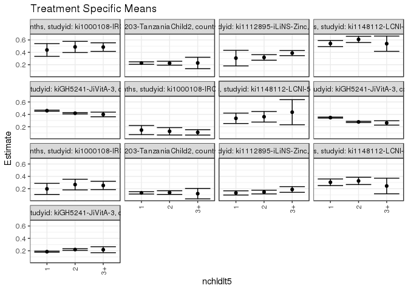

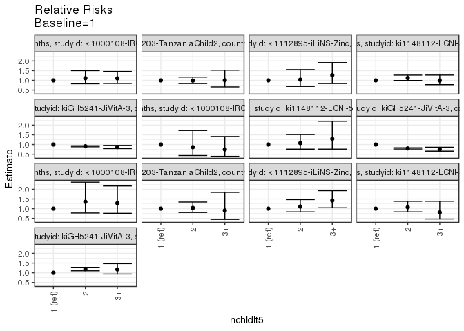

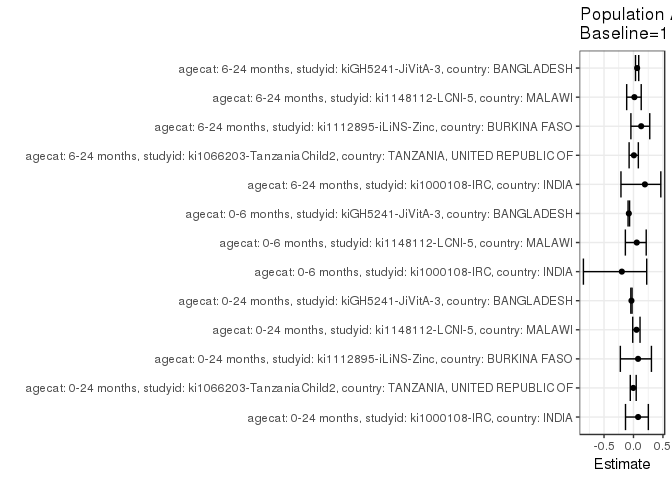

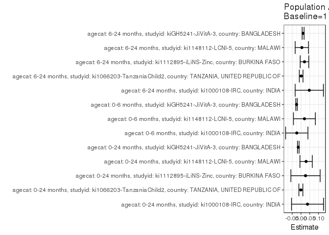

## Results Table

### Parameter: TSM

| agecat | studyid | country | intervention_level | baseline_level | estimate | ci_lower | ci_upper |
| --- | --- | --- | --- | --- | --- | --- | --- |
| 0-24 months | ki1000108-IRC | INDIA | 1 | NA | 0.4382022 | 0.3349949 | 0.5414096 |
| 0-24 months | ki1000108-IRC | INDIA | 2 | NA | 0.4873950 | 0.3974790 | 0.5773109 |
| 0-24 months | ki1000108-IRC | INDIA | 3+ | NA | 0.4851485 | 0.4161434 | 0.5541536 |
| 0-24 months | ki1066203-TanzaniaChild2 | TANZANIA, UNITED REPUBLIC OF | 1 | NA | 0.2266341 | 0.2063493 | 0.2469189 |
| 0-24 months | ki1066203-TanzaniaChild2 | TANZANIA, UNITED REPUBLIC OF | 2 | NA | 0.2242152 | 0.1926049 | 0.2558256 |
| 0-24 months | ki1066203-TanzaniaChild2 | TANZANIA, UNITED REPUBLIC OF | 3+ | NA | 0.2278481 | 0.1353358 | 0.3203604 |
| 0-24 months | ki1112895-iLiNS-Zinc | BURKINA FASO | 1 | NA | 0.3066170 | 0.1809873 | 0.4322466 |
| 0-24 months | ki1112895-iLiNS-Zinc | BURKINA FASO | 2 | NA | 0.3176101 | 0.2726858 | 0.3625343 |
| 0-24 months | ki1112895-iLiNS-Zinc | BURKINA FASO | 3+ | NA | 0.3879004 | 0.3466521 | 0.4291487 |
| 0-24 months | ki1148112-LCNI-5 | MALAWI | 1 | NA | 0.5421995 | 0.4927861 | 0.5916129 |
| 0-24 months | ki1148112-LCNI-5 | MALAWI | 2 | NA | 0.6089385 | 0.5583580 | 0.6595191 |
| 0-24 months | ki1148112-LCNI-5 | MALAWI | 3+ | NA | 0.5396825 | 0.4165300 | 0.6628351 |
| 0-24 months | kiGH5241-JiVitA-3 | BANGLADESH | 1 | NA | 0.4591708 | 0.4500647 | 0.4682768 |
| 0-24 months | kiGH5241-JiVitA-3 | BANGLADESH | 2 | NA | 0.4178045 | 0.4066484 | 0.4289606 |
| 0-24 months | kiGH5241-JiVitA-3 | BANGLADESH | 3+ | NA | 0.3984375 | 0.3610625 | 0.4358125 |
| 0-6 months | ki1000108-IRC | INDIA | 1 | NA | 0.1460674 | 0.0726039 | 0.2195310 |
| 0-6 months | ki1000108-IRC | INDIA | 2 | NA | 0.1260504 | 0.0663441 | 0.1857567 |
| 0-6 months | ki1000108-IRC | INDIA | 3+ | NA | 0.1089109 | 0.0658980 | 0.1519238 |
| 0-6 months | ki1148112-LCNI-5 | MALAWI | 1 | NA | 0.3360656 | 0.2520891 | 0.4200420 |
| 0-6 months | ki1148112-LCNI-5 | MALAWI | 2 | NA | 0.3606557 | 0.2752874 | 0.4460241 |
| 0-6 months | ki1148112-LCNI-5 | MALAWI | 3+ | NA | 0.4347826 | 0.2318075 | 0.6377577 |
| 0-6 months | kiGH5241-JiVitA-3 | BANGLADESH | 1 | NA | 0.3473478 | 0.3389751 | 0.3557205 |
| 0-6 months | kiGH5241-JiVitA-3 | BANGLADESH | 2 | NA | 0.2778689 | 0.2682671 | 0.2874708 |
| 0-6 months | kiGH5241-JiVitA-3 | BANGLADESH | 3+ | NA | 0.2613459 | 0.2260520 | 0.2966397 |
| 6-24 months | ki1000108-IRC | INDIA | 1 | NA | 0.1973684 | 0.1077536 | 0.2869832 |
| 6-24 months | ki1000108-IRC | INDIA | 2 | NA | 0.2673267 | 0.1808886 | 0.3537648 |
| 6-24 months | ki1000108-IRC | INDIA | 3+ | NA | 0.2530864 | 0.1860360 | 0.3201369 |
| 6-24 months | ki1066203-TanzaniaChild2 | TANZANIA, UNITED REPUBLIC OF | 1 | NA | 0.1332808 | 0.1145684 | 0.1519932 |
| 6-24 months | ki1066203-TanzaniaChild2 | TANZANIA, UNITED REPUBLIC OF | 2 | NA | 0.1381323 | 0.1082955 | 0.1679691 |
| 6-24 months | ki1066203-TanzaniaChild2 | TANZANIA, UNITED REPUBLIC OF | 3+ | NA | 0.1206897 | 0.0368290 | 0.2045503 |
| 6-24 months | ki1112895-iLiNS-Zinc | BURKINA FASO | 1 | NA | 0.1325167 | 0.0987802 | 0.1662532 |
| 6-24 months | ki1112895-iLiNS-Zinc | BURKINA FASO | 2 | NA | 0.1466165 | 0.1165306 | 0.1767025 |
| 6-24 months | ki1112895-iLiNS-Zinc | BURKINA FASO | 3+ | NA | 0.1881481 | 0.1421128 | 0.2341835 |
| 6-24 months | ki1148112-LCNI-5 | MALAWI | 1 | NA | 0.3041958 | 0.2508301 | 0.3575615 |
| 6-24 months | ki1148112-LCNI-5 | MALAWI | 2 | NA | 0.3265306 | 0.2677596 | 0.3853016 |
| 6-24 months | ki1148112-LCNI-5 | MALAWI | 3+ | NA | 0.2444444 | 0.1187713 | 0.3701176 |
| 6-24 months | kiGH5241-JiVitA-3 | BANGLADESH | 1 | NA | 0.1847623 | 0.1755855 | 0.1939392 |
| 6-24 months | kiGH5241-JiVitA-3 | BANGLADESH | 2 | NA | 0.2193854 | 0.2057185 | 0.2330524 |
| 6-24 months | kiGH5241-JiVitA-3 | BANGLADESH | 3+ | NA | 0.2167832 | 0.1686127 | 0.2649537 |

### Parameter: E(Y)

| agecat | studyid | country | intervention_level | baseline_level | estimate | ci_lower | ci_upper |
| --- | --- | --- | --- | --- | --- | --- | --- |
| 0-24 months | ki1000108-IRC | INDIA | NA | NA | 0.4756098 | 0.4272105 | 0.5240091 |
| 0-24 months | ki1066203-TanzaniaChild2 | TANZANIA, UNITED REPUBLIC OF | NA | NA | 0.2259958 | 0.2092071 | 0.2427845 |
| 0-24 months | ki1112895-iLiNS-Zinc | BURKINA FASO | NA | NA | 0.3324969 | 0.2814472 | 0.3835465 |
| 0-24 months | ki1148112-LCNI-5 | MALAWI | NA | NA | 0.5714286 | 0.5373697 | 0.6054874 |
| 0-24 months | kiGH5241-JiVitA-3 | BANGLADESH | NA | NA | 0.4438237 | 0.4363002 | 0.4513472 |
| 0-6 months | ki1000108-IRC | INDIA | NA | NA | 0.1219512 | 0.0902381 | 0.1536643 |
| 0-6 months | ki1148112-LCNI-5 | MALAWI | NA | NA | 0.3558052 | 0.2982716 | 0.4133389 |
| 0-6 months | kiGH5241-JiVitA-3 | BANGLADESH | NA | NA | 0.3219246 | 0.3151663 | 0.3286829 |
| 6-24 months | ki1000108-IRC | INDIA | NA | NA | 0.2448378 | 0.1989973 | 0.2906782 |
| 6-24 months | ki1066203-TanzaniaChild2 | TANZANIA, UNITED REPUBLIC OF | NA | NA | 0.1342391 | 0.1186581 | 0.1498201 |
| 6-24 months | ki1112895-iLiNS-Zinc | BURKINA FASO | NA | NA | 0.1524460 | 0.1260328 | 0.1788591 |
| 6-24 months | ki1148112-LCNI-5 | MALAWI | NA | NA | 0.3090278 | 0.2712581 | 0.3467975 |
| 6-24 months | kiGH5241-JiVitA-3 | BANGLADESH | NA | NA | 0.1969765 | 0.1889146 | 0.2050384 |

### Parameter: RR

| agecat | studyid | country | intervention_level | baseline_level | estimate | ci_lower | ci_upper |
| --- | --- | --- | --- | --- | --- | --- | --- |
| 0-24 months | ki1000108-IRC | INDIA | 1 | 1 | 1.0000000 | 1.0000000 | 1.0000000 |
| 0-24 months | ki1000108-IRC | INDIA | 2 | 1 | 1.1122603 | 0.8246628 | 1.5001562 |
| 0-24 months | ki1000108-IRC | INDIA | 3+ | 1 | 1.1071338 | 0.8408294 | 1.4577811 |
| 0-24 months | ki1066203-TanzaniaChild2 | TANZANIA, UNITED REPUBLIC OF | 1 | 1 | 1.0000000 | 1.0000000 | 1.0000000 |
| 0-24 months | ki1066203-TanzaniaChild2 | TANZANIA, UNITED REPUBLIC OF | 2 | 1 | 0.9893271 | 0.8371732 | 1.1691346 |
| 0-24 months | ki1066203-TanzaniaChild2 | TANZANIA, UNITED REPUBLIC OF | 3+ | 1 | 1.0053567 | 0.6633635 | 1.5236625 |
| 0-24 months | ki1112895-iLiNS-Zinc | BURKINA FASO | 1 | 1 | 1.0000000 | 1.0000000 | 1.0000000 |
| 0-24 months | ki1112895-iLiNS-Zinc | BURKINA FASO | 2 | 1 | 1.0358529 | 0.6899387 | 1.5551978 |
| 0-24 months | ki1112895-iLiNS-Zinc | BURKINA FASO | 3+ | 1 | 1.2650975 | 0.8360457 | 1.9143351 |
| 0-24 months | ki1148112-LCNI-5 | MALAWI | 1 | 1 | 1.0000000 | 1.0000000 | 1.0000000 |
| 0-24 months | ki1148112-LCNI-5 | MALAWI | 2 | 1 | 1.1230895 | 0.9928002 | 1.2704771 |
| 0-24 months | ki1148112-LCNI-5 | MALAWI | 3+ | 1 | 0.9953579 | 0.7785105 | 1.2726063 |
| 0-24 months | kiGH5241-JiVitA-3 | BANGLADESH | 1 | 1 | 1.0000000 | 1.0000000 | 1.0000000 |
| 0-24 months | kiGH5241-JiVitA-3 | BANGLADESH | 2 | 1 | 0.9099109 | 0.8824776 | 0.9381969 |
| 0-24 months | kiGH5241-JiVitA-3 | BANGLADESH | 3+ | 1 | 0.8677327 | 0.7900078 | 0.9531045 |
| 0-6 months | ki1000108-IRC | INDIA | 1 | 1 | 1.0000000 | 1.0000000 | 1.0000000 |
| 0-6 months | ki1000108-IRC | INDIA | 2 | 1 | 0.8629606 | 0.4324598 | 1.7220119 |
| 0-6 months | ki1000108-IRC | INDIA | 3+ | 1 | 0.7456207 | 0.3933672 | 1.4133112 |
| 0-6 months | ki1148112-LCNI-5 | MALAWI | 1 | 1 | 1.0000000 | 1.0000000 | 1.0000000 |
| 0-6 months | ki1148112-LCNI-5 | MALAWI | 2 | 1 | 1.0731707 | 0.7606548 | 1.5140842 |
| 0-6 months | ki1148112-LCNI-5 | MALAWI | 3+ | 1 | 1.2937434 | 0.7618756 | 2.1969097 |
| 0-6 months | kiGH5241-JiVitA-3 | BANGLADESH | 1 | 1 | 1.0000000 | 1.0000000 | 1.0000000 |
| 0-6 months | kiGH5241-JiVitA-3 | BANGLADESH | 2 | 1 | 0.7999732 | 0.7693037 | 0.8318655 |
| 0-6 months | kiGH5241-JiVitA-3 | BANGLADESH | 3+ | 1 | 0.7524039 | 0.6567838 | 0.8619452 |
| 6-24 months | ki1000108-IRC | INDIA | 1 | 1 | 1.0000000 | 1.0000000 | 1.0000000 |
| 6-24 months | ki1000108-IRC | INDIA | 2 | 1 | 1.3544554 | 0.7756806 | 2.3650837 |
| 6-24 months | ki1000108-IRC | INDIA | 3+ | 1 | 1.2823045 | 0.7580321 | 2.1691759 |
| 6-24 months | ki1066203-TanzaniaChild2 | TANZANIA, UNITED REPUBLIC OF | 1 | 1 | 1.0000000 | 1.0000000 | 1.0000000 |
| 6-24 months | ki1066203-TanzaniaChild2 | TANZANIA, UNITED REPUBLIC OF | 2 | 1 | 1.0364009 | 0.8010221 | 1.3409453 |
| 6-24 months | ki1066203-TanzaniaChild2 | TANZANIA, UNITED REPUBLIC OF | 3+ | 1 | 0.9055295 | 0.4456938 | 1.8397917 |
| 6-24 months | ki1112895-iLiNS-Zinc | BURKINA FASO | 1 | 1 | 1.0000000 | 1.0000000 | 1.0000000 |
| 6-24 months | ki1112895-iLiNS-Zinc | BURKINA FASO | 2 | 1 | 1.1064005 | 0.8337556 | 1.4682024 |
| 6-24 months | ki1112895-iLiNS-Zinc | BURKINA FASO | 3+ | 1 | 1.4198070 | 1.0456949 | 1.9277630 |
| 6-24 months | ki1148112-LCNI-5 | MALAWI | 1 | 1 | 1.0000000 | 1.0000000 | 1.0000000 |
| 6-24 months | ki1148112-LCNI-5 | MALAWI | 2 | 1 | 1.0734225 | 0.8348633 | 1.3801491 |
| 6-24 months | ki1148112-LCNI-5 | MALAWI | 3+ | 1 | 0.8035760 | 0.4667748 | 1.3833958 |
| 6-24 months | kiGH5241-JiVitA-3 | BANGLADESH | 1 | 1 | 1.0000000 | 1.0000000 | 1.0000000 |
| 6-24 months | kiGH5241-JiVitA-3 | BANGLADESH | 2 | 1 | 1.1873926 | 1.1014889 | 1.2799958 |
| 6-24 months | kiGH5241-JiVitA-3 | BANGLADESH | 3+ | 1 | 1.1733084 | 0.9361025 | 1.4706217 |

### Parameter: PAR

| agecat | studyid | country | intervention_level | baseline_level | estimate | ci_lower | ci_upper |
| --- | --- | --- | --- | --- | --- | --- | --- |
| 0-24 months | ki1000108-IRC | INDIA | 1 | NA | 0.0374075 | -0.0540793 | 0.1288943 |
| 0-24 months | ki1066203-TanzaniaChild2 | TANZANIA, UNITED REPUBLIC OF | 1 | NA | -0.0006383 | -0.0119734 | 0.0106969 |
| 0-24 months | ki1112895-iLiNS-Zinc | BURKINA FASO | 1 | NA | 0.0258799 | -0.0577785 | 0.1095383 |
| 0-24 months | ki1148112-LCNI-5 | MALAWI | 1 | NA | 0.0292291 | -0.0061293 | 0.0645875 |
| 0-24 months | kiGH5241-JiVitA-3 | BANGLADESH | 1 | NA | -0.0153470 | -0.0199647 | -0.0107294 |
| 0-6 months | ki1000108-IRC | INDIA | 1 | NA | -0.0241162 | -0.0878310 | 0.0395986 |
| 0-6 months | ki1148112-LCNI-5 | MALAWI | 1 | NA | 0.0197397 | -0.0428511 | 0.0823304 |
| 0-6 months | kiGH5241-JiVitA-3 | BANGLADESH | 1 | NA | -0.0254232 | -0.0295935 | -0.0212529 |
| 6-24 months | ki1000108-IRC | INDIA | 1 | NA | 0.0474693 | -0.0333473 | 0.1282860 |
| 6-24 months | ki1066203-TanzaniaChild2 | TANZANIA, UNITED REPUBLIC OF | 1 | NA | 0.0009584 | -0.0095449 | 0.0114616 |
| 6-24 months | ki1112895-iLiNS-Zinc | BURKINA FASO | 1 | NA | 0.0199293 | -0.0045030 | 0.0443615 |
| 6-24 months | ki1148112-LCNI-5 | MALAWI | 1 | NA | 0.0048320 | -0.0331986 | 0.0428626 |
| 6-24 months | kiGH5241-JiVitA-3 | BANGLADESH | 1 | NA | 0.0122142 | 0.0068203 | 0.0176081 |

### Parameter: PAF

| agecat | studyid | country | intervention_level | baseline_level | estimate | ci_lower | ci_upper |
| --- | --- | --- | --- | --- | --- | --- | --- |
| 0-24 months | ki1000108-IRC | INDIA | 1 | NA | 0.0786517 | -0.1353962 | 0.2523467 |
| 0-24 months | ki1066203-TanzaniaChild2 | TANZANIA, UNITED REPUBLIC OF | 1 | NA | -0.0028243 | -0.0542560 | 0.0460983 |
| 0-24 months | ki1112895-iLiNS-Zinc | BURKINA FASO | 1 | NA | 0.0778350 | -0.2230249 | 0.3046844 |
| 0-24 months | ki1148112-LCNI-5 | MALAWI | 1 | NA | 0.0511509 | -0.0129111 | 0.1111612 |
| 0-24 months | kiGH5241-JiVitA-3 | BANGLADESH | 1 | NA | -0.0345791 | -0.0450100 | -0.0242524 |
| 0-6 months | ki1000108-IRC | INDIA | 1 | NA | -0.1977528 | -0.8500931 | 0.2245732 |
| 0-6 months | ki1148112-LCNI-5 | MALAWI | 1 | NA | 0.0554789 | -0.1378937 | 0.2159899 |
| 0-6 months | kiGH5241-JiVitA-3 | BANGLADESH | 1 | NA | -0.0789725 | -0.0919024 | -0.0661957 |
| 6-24 months | ki1000108-IRC | INDIA | 1 | NA | 0.1938808 | -0.2125962 | 0.4641018 |
| 6-24 months | ki1066203-TanzaniaChild2 | TANZANIA, UNITED REPUBLIC OF | 1 | NA | 0.0071393 | -0.0742659 | 0.0823759 |
| 6-24 months | ki1112895-iLiNS-Zinc | BURKINA FASO | 1 | NA | 0.1307300 | -0.0438836 | 0.2761354 |
| 6-24 months | ki1148112-LCNI-5 | MALAWI | 1 | NA | 0.0156360 | -0.1154509 | 0.1313177 |
| 6-24 months | kiGH5241-JiVitA-3 | BANGLADESH | 1 | NA | 0.0620083 | 0.0343975 | 0.0888297 |